# How to: Make a dot plot

Jonathan Tan

08/11/2021

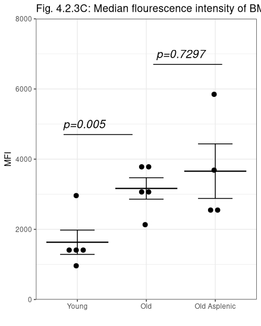

## Understanding your data

Example: Comparing CD150hi (myeloid-biased) HSC between young and old animals

When thinking about your data, identify the following:

1. What are you comparing **(independent variables)**?
- *Young and old animals (ie. Category = Age)*
2. What is your measurement **(dependent variables)**?
- *The MFI of CD150<sup>hi</sup> HSC (Category = HSC)*

## Import data from a Prism file

List all the data tables in the Prism file.

```r
library(pzfx)
pzfx_tables("../data/young vs old graphs JTmod.pzfx")
```

```
##  [1] "Data 1"                          "Data 2 YnO %"
##  [3] "Data 3"                          "Data 4"
##  [5] "Data 5 Exb %"                    "Data 6"
##  [7] "Data 8"                          "Data 9"
##  [9] "Data 10"                         "Data 11"
## [11] "Data 12"                         "Data 13"
## [13] "Data 14"                         "Data 15"
## [15] "Data 16"                         "New Copy of Data 2 YnO %"
## [17] "New Copy of Data 5 Exb %"        "Data 17 exb for col stats"
## [19] "Data 18 YvOvOa for col stats"    "absolute YOOA %"
## [21] "Column: Entering replicate data" "Copy of Data 15"
## [23] "Data 19"                         "Data 20"
## [25] "Data 21"                         "Figure 4.2.3B"
## [27] "Data 22"                         "Data 23"
## [29] "Data 24"
```

Now we can select which data table to import:

```r
data1 <- read_pzfx("../data/young vs old graphs JTmod.pzfx", "Data 1")
head(data1, N = 6)
```

```
##   Young  Old Old Asplenic
## 1  1276 3104         2570
## 2  2961 3687         2527
## 3  1541 2133         3687
## 4  1422 3876         5848
## 5   961 3027           NA
```

Oh no! The data is in a format which RStudio can’t read!

We need to arrange this dataset so that each column lists a variable (Age, HSC).

Fortunately, we can call on the “pivot_longer” function to convert data into “Tall format”:

```r
library(tidyverse)
data1.tall <- data1 %>% select(Young, Old, "Old Asplenic") %>%
  pivot_longer(., cols = c(Young,Old,"Old Asplenic"), names_to = "Age", values_to = "HSC") ## Concatenate columns (Young, Old, Old Asplenic) into one column (age)
head (data1.tall)
```

```
## # A tibble: 6 × 2
##   Age            HSC
##   <chr>        <dbl>
## 1 Young         1276
## 2 Old           3104
## 3 Old Asplenic  2570
## 4 Young         2961
## 5 Old           3687
## 6 Old Asplenic  2527
```

Now all the observations (values for HSC MFI) are listed in one column.

## Run descriptive statistics

We will now find the average MFI for all treatment groups (Average = mean(HSC)).

```r
data1.tall %>%
  select(Age, HSC) %>%
  filter(Age == "Young"|
           Age == "Old"|
           Age == "Old Asplenic") %>%
  na.omit() %>% # Omit values with 'NA'
  group_by(Age) %>%
  summarise(Average = mean(HSC))
```

```
## # A tibble: 3 × 2
##   Age          Average
##   <chr>          <dbl>
## 1 Old            3165.
## 2 Old Asplenic   3658
## 3 Young          1632.
```

## To perform an unpaired two-sample t-test, create dataframe pairs for comparison

```r
data1.youngvsold <- data1.tall %>%
  select(Age, HSC) %>%
  filter(Age == "Young"|
           Age == "Old") %>%
  na.omit()
View(data1.youngvsold)
```

```r
data1.oldvsoldasplenic <- data1.tall %>%
  select(Age, HSC) %>%
  filter(Age == "Old"|
           Age == "Old Asplenic") %>%
  na.omit()
View(data1.oldvsoldasplenic)
```

## Background statistics information

Unpaired two-samples t-test can be used only under certain conditions:

1. When the two groups of samples (A and B), being compared, are normally distributed. This can be checked using Shapiro-Wilk test.
2. When the variances of the two groups are equal. This can be checked using F-test.

http://www.sthda.com/english/wiki/unpaired-two-samples-t-test-in-r

## Shapiro-Wilk normality test

Null hypothesis: the data are normally distributed

Alternative hypothesis: the data are not normally distributed

To test %HSC in young animals:

```r
with(data1.tall, shapiro.test(HSC[Age == "Young"]))
```

```
##
##  Shapiro-Wilk normality test
##
## data:  HSC[Age == "Young"]
## W = 0.81028, p-value = 0.09802
```

To test %HSC in old animals:

```r
with(data1.tall, shapiro.test(HSC[Age == "Old"]))
```

```
##
##  Shapiro-Wilk normality test
##
## data:  HSC[Age == "Old"]
## W = 0.9307, p-value = 0.6012
```

To test %HSC in Old asplenic animals:

```r
with(data1.tall, shapiro.test(HSC[Age == "Old Asplenic"]))
```

```
##
##  Shapiro-Wilk normality test
##
## data:  HSC[Age == "Old Asplenic"]
## W = 0.83914, p-value = 0.1929
```

From the outputs, the p-values are greater than the significance level 0.05.

This implies the distribution of the data are not significantly different from the normal distribution.

In other words, we can assume the normality.

## F-test to test for homogeneity in variances

```r
var.test(HSC ~ Age, data = data1.youngvsold)
```

```
##
##  F test to compare two variances
##
## data:  HSC by Age
## F = 0.77884, num df = 4, denom df = 4, p-value = 0.8145
## alternative hypothesis: true ratio of variances is not equal to 1
## 95 percent confidence interval:
##  0.08109112 7.48041222
## sample estimates:
## ratio of variances
##          0.7788421
```

```r
var.test(HSC ~ Age, data = data1.oldvsoldasplenic)
```

```
##
##  F test to compare two variances
##
## data:  HSC by Age
## F = 0.19275, num df = 4, denom df = 3, p-value = 0.1456
## alternative hypothesis: true ratio of variances is not equal to 1
## 95 percent confidence interval:
##  0.01276416 1.92350369
## sample estimates:
## ratio of variances
##          0.1927513
```

The p-values of F-test are greater than the significance level 0.05

This implies there is no significant difference between the variances of the two sets of data.

Therefore, we can use the classic t-test witch assume equality of the two variances.

Note that:

1. If the variance of the two groups are equivalent (homoscedasticity; var.equal = TRUE), the student t-test value can be used
2. If the variance of the two groups are different (heteroscedasticity; var.equal = FALSE), it’s possible to use the Welch t test, an adaptation of Student t-test

## Running a one-tailed students t-test

The following hypotheses are first defined:

1. H0:mA≤mB, ie. Null hypothesis: HSC(old) is less than or equal to HSC(young[control])
2. Ha:mA>mB (greater), ie. Alternative hypothesis: HSC(old) is greater than HSC(young)

```r
t.test(data = data1.youngvsold, HSC ~ Age, var.equal = TRUE, alternative = "greater")
```

```
##
##  Two Sample t-test
##
## data:  HSC by Age
## t = 3.3215, df = 8, p-value = 0.005258
## alternative hypothesis: true difference in means between group Old and group Young is greater than 0
## 95 percent confidence interval:
##  674.8426      Inf
## sample estimates:
##   mean in group Old mean in group Young
##              3165.4              1632.2
```

```r
## If the observed difference went in the direction predicted by the experimental hypothesis,
## the one-tailed P value is half the two-tailed P value (with most, but not quite all, statistical tests).
```

```r
t.test(data = data1.oldvsoldasplenic, HSC ~ Age, var.equal = TRUE, alternative = "greater")
```

```
##
##  Two Sample t-test
##
## data:  HSC by Age
## t = -0.64314, df = 7, p-value = 0.7297
## alternative hypothesis: true difference in means between group Old and group Old Asplenic is greater than 0
## 95 percent confidence interval:
##  -1943.714       Inf
## sample estimates:
##          mean in group Old mean in group Old Asplenic
##                     3165.4                     3658.0
```

Here, we can see that there is a significant difference between young and old animals (p=0.005), but there is no significant difference between old and old-asplenic animals (p=0.7297).

## Compute summary statistics

Before we make a bar graph with pvalues, we need to compute summary statistics for the variable “HSC” organised into groups by the variable “Age”.

https://www.datanovia.com/en/lessons/ggplot-error-bars/

First, we will compute the standard error:

https://www.r-graph-gallery.com/4-barplot-with-error-bar.html

```r
data1.tallna <- data1.tall %>% na.omit() # Omit values in the dataframe with NA
view(data1.tallna)
data1.tallna.summary <- data1.tallna %>%
  group_by(Age) %>%
  summarise(
    n=n(),
    sd = sd(HSC, na.rm = TRUE), ## Handling missing data: If there are NA’s in the data, you need to pass the flag na.rm=TRUE
    HSC = mean(HSC)
  ) %>%
  mutate( se=sd/sqrt(n))
data1.tallna.summary
```

```
## # A tibble: 3 × 5
##   Age              n    sd   HSC    se
##   <chr>        <int> <dbl> <dbl> <dbl>
## 1 Old              5  683. 3165.  305.
## 2 Old Asplenic     4 1556. 3658   778.
## 3 Young            5  774. 1632.  346.
```

## Create a dot plot with means + standard errors + annotations

https://www.datanovia.com/en/lessons/ggplot-error-bars/

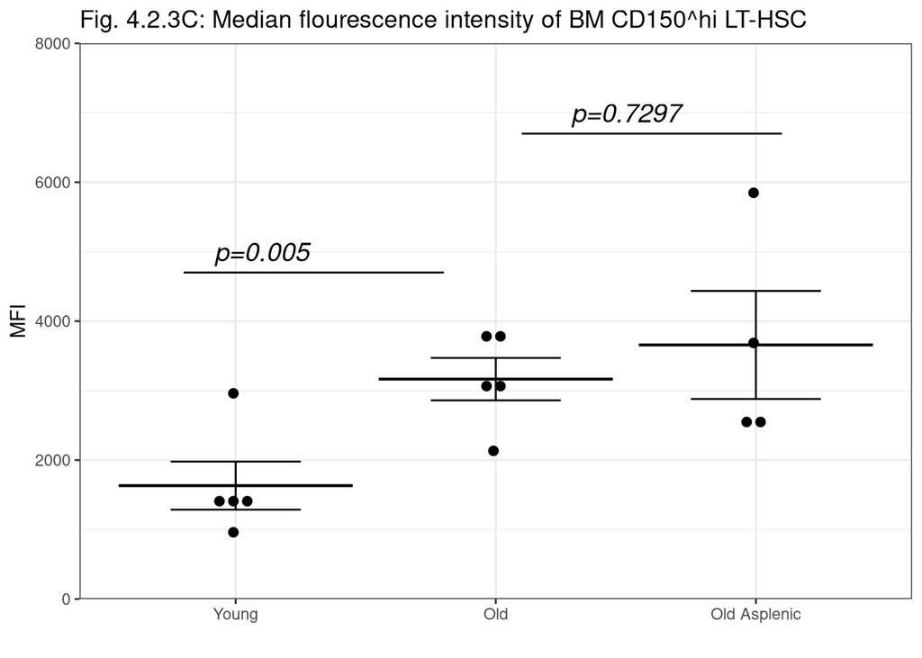

```r
data1.tallna %>%
  ggplot(aes(Age,HSC, shape=Age)) +
  scale_x_discrete(limits = c("Young", "Old", "Old Asplenic")) +
  scale_y_continuous(expand = c(0, 0), limits = c(0, 8000)) +
  geom_errorbar( aes(ymin = HSC-se, ymax = HSC+se),
                 data = data1.tallna.summary, width = 0.5) +
  stat_summary(fun=mean, geom="crossbar",
               size=0.3, color="black") +
  geom_dotplot(binaxis='y', stackdir='center',
               stackratio=1.5, dotsize=0.5) +
  theme(legend.position="none") +
  theme_bw()+
  labs(x = "",
       y = "MFI",
       title = "Fig. 4.2.3C: Median flourescence intensity of BM CD150^hi LT-HSC") +
  annotate("text", x = c(1.1,2.5), y = c(5000,7000),
           label = c("p=0.005", "p=0.7297") , color="black",
           size=5 , angle=0, fontface="italic") +
  annotate(geom = "segment", x = c(0.8,2.1), xend = c(1.8,3.1), y = c(4700,6700), yend = c(4700,6700), colour = "#060606")
```

**Congratulations!**

We have created an annotated dot plot showing statistics (standard error bars, p-value for one-tailed students t-tests)

- We have 1 categorical variable (Age) and one numeric variable (MFI)
- The categorical (independent) variable is plotted on the x-axis (x=Age)
- The numerical (dependent) variable is plotted on the y-axis (HSC)